# Workshop Practice Material

2024-10-27

## Practice Questions and Solutions (Solve using the nycflights13 dataset)

```r
#Loading required packages
library(dplyr)
library(ggplot2)
library(lubridate)
library(nycflights13)
```

### Question 1: Analyzing Delays by Day of the Week

**1.1.** Create a new column `dep_date` by combining the `year`, `month`, and `day` columns using `make_date()`.

```r
flights <- flights |>
    mutate(dep_date = make_date(year, month, day))
```

**1.2.** Use the `wday()` accessor function to extract the day of the week from `dep_date`, creating a new column called `day_of_week`.

```r
flights <- flights |>
    mutate(day_of_week = wday(dep_date, label = TRUE))
```

**1.3.** Calculate the average `dep_delay` by min for each day of the week. Which day has the highest average delay?

```r
avg_delay_by_day <- flights %>%
    group_by(day_of_week) %>%
    summarise(avg_delay = mean(dep_delay, na.rm = TRUE))
```

**1.4.** Create a bar graph visualizing the average departure delays for each day of the week.

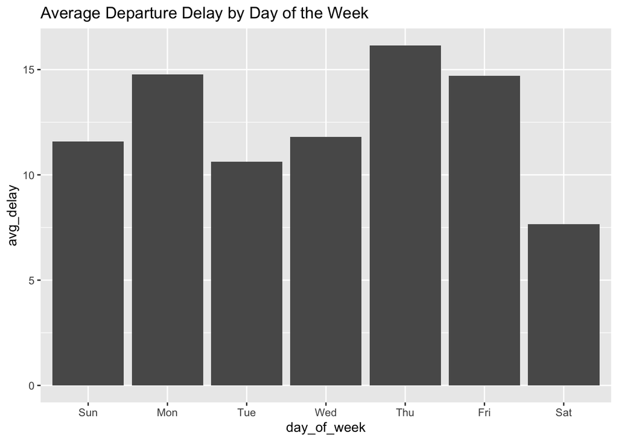

```r
ggplot(avg_delay_by_day, aes(x = day_of_week, y = avg_delay)) +
    geom_bar(stat = "identity") +
    labs(title = "Average Departure Delay by Day of the Week")
```

### Question 2: Seasonal Flight Patterns

**2.1.** Create a new column `arr_date` using from the `year`, `month`, and `day` columns for arrival.

```r
flights <- flights %>%
    mutate(arr_date = make_date(year, month, day))
```

**2.2.** Use the `month()` accessor function to categorize flights into seasons based on the `arr_date`.

```r
flights <- flights %>%
    mutate(season = case_when(
        month(arr_date) %in% c(12, 1, 2) ~ "Winter",
        month(arr_date) %in% c(3, 4, 5) ~ "Spring",
        month(arr_date) %in% c(6, 7, 8) ~ "Summer",
        month(arr_date) %in% c(9, 10, 11) ~ "Fall"
    ))
```

**2.3.** Analyze how the total number of flights varies by season. Generate a pie chart showing the proportion of flights for each season.

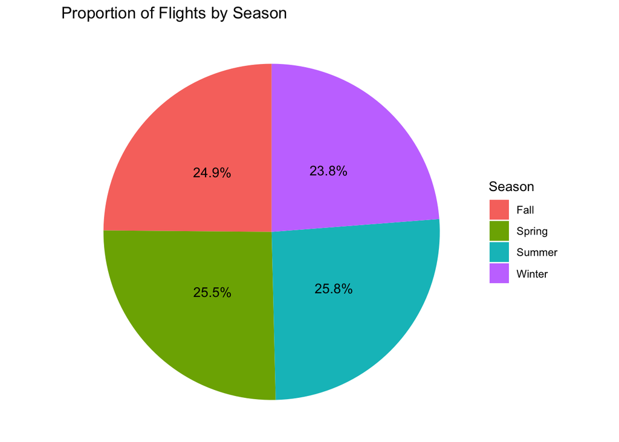

```r
flights_by_season <- flights %>%
    group_by(season) %>%
    summarise(total_flights = n()) %>%
    mutate(percentage = total_flights / sum(total_flights) * 100)


ggplot(flights_by_season, aes(x = "", y = percentage, fill = season)) +
    geom_bar(stat = "identity") +
    coord_polar(theta = "y") +
    labs(title = "Proportion of Flights by Season",
         fill = "Season") +
    geom_text(aes(label = paste0(round(percentage, 1), "%")),
              position = position_stack(vjust = 0.5)) +
    theme_void()
```

### Question 3: Flight Durations

**3.1.** Calculate the actual flight duration from `arr_time` and `dep_time` in minutes. Create a new column called `actual_duration`.

```r
library(dplyr)
library(lubridate)

flights <- flights |>
  mutate(dep_time_dt = make_datetime(year, month, day, dep_time %/% 100, dep_time %% 100),
         arr_time_dt = make_datetime(year, month, day, arr_time %/% 100, arr_time %% 100),
         actual_duration = as.duration(arr_time_dt - dep_time_dt) / dminutes(1)  # Convert to minutes
    )
```

**3.2.** Investigate trends in flight durations over the months. Create a line plot to visualize average flight duration by month.

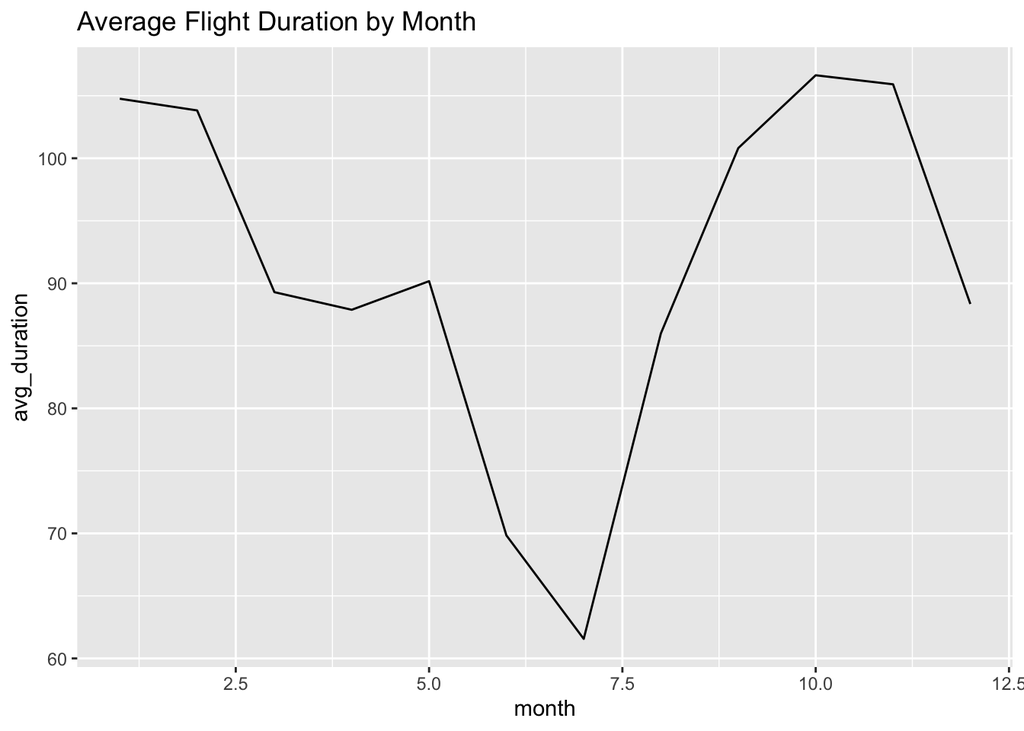

```r
avg_duration_by_month <- flights %>%
    group_by(month) %>%
    summarise(avg_duration = mean(actual_duration, na.rm = TRUE))

ggplot(avg_duration_by_month, aes(x = month, y = avg_duration)) +
    geom_line() +
    labs(title = "Average Flight Duration by Month")
```

### Question 5: Hourly Patterns of Departures

**5.1.** Create a new column called `departure_hour`.

```r
flights <- flights %>%
    mutate(departure_hour = hour(dep_time_dt))
```

**5.2.** Determine if there are peak hours for departures and plot to visualize the frequency of flights departing by hour.

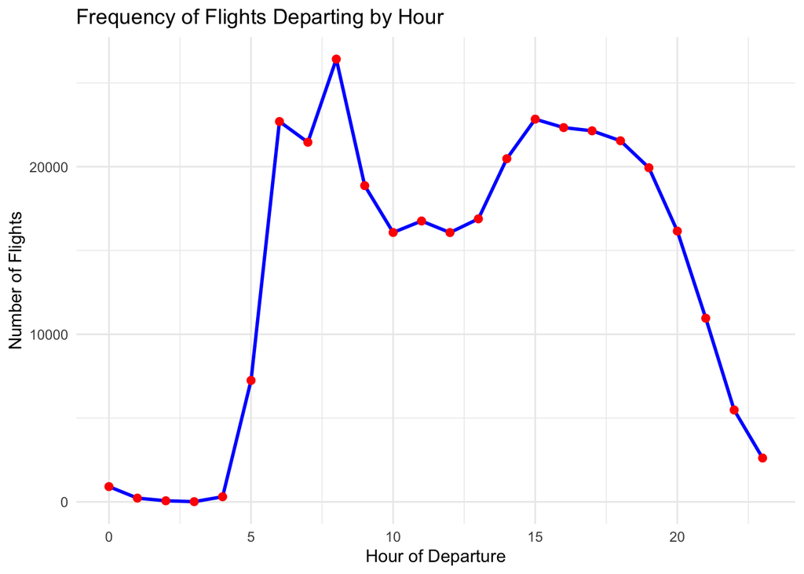

```r
# Count the number of flights departing each hour
flights_by_hour <- flights %>%
    group_by(departure_hour) %>%
    summarise(flight_count = n(), .groups = 'drop')

# Plot the frequency of flights departing by hour
ggplot(flights_by_hour, aes(x = departure_hour, y = flight_count)) +
    geom_line(color = "blue", size = 1) +  # Customize line color and size
    geom_point(color = "red", size = 2) +  # Optional: Add points for emphasis
    labs(
        title = "Frequency of Flights Departing by Hour",
        x = "Hour of Departure",
        y = "Number of Flights"
    ) +
    theme_minimal()
```

**5.3.** Please plot the number of flights per week.

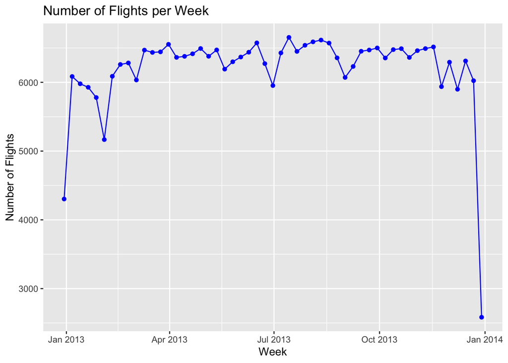

```r
flights_dt <- flights |>
  filter(!is.na(dep_time_dt)) # Filter out any rows with NA dep_time

# Plotting the number of flights per week
weekly_flights <- flights_dt %>%
  count(week = floor_date(dep_time_dt, "week"))

ggplot(weekly_flights, aes(x = week, y = n)) +
  geom_line(color = "blue") +
  geom_point(color = "blue") +
  labs(title = "Number of Flights per Week", x = "Week", y = "Number of Flights")
```